# emmeans Notes

F.A. Barrios

2020-12-03

```r
library(tidyverse)
library(car)
library(emmeans)
library(effects)
```

# Notes from emmeans [^1]

In a linear model with one factor, a One-Way Analysis of Variance. In the example of Baumann that conducted an experiment with 66 children, assigning at random to one of three experimental groups. The groups represent different different methods of teaching reading: a standard `Basal` and two new methods called `DTRA` and `Strat`. With two pre-tests and three post-tests of reading and comprehension.

```r
summary(Baumann[, c(1, 6)])
```

```
   group     post.test.3
 Basal:22   Min.   :30.00
 DRTA :22   1st Qu.:40.00
 Strat:22   Median :45.00
            Mean   :44.02
            3rd Qu.:49.00
            Max.   :57.00
```

```r
xtabs(~ group, data=Baumann)
```

```
group
Basal  DRTA Strat
   22    22    22
```

xtabs in a one sided formula “counts” the number of cases.

```r
Tapply(post.test.3 ~ group, mean, data=Baumann)
```

```
   Basal     DRTA    Strat
41.04545 46.72727 44.27273
```

```r
Tapply(post.test.3 ~ group, sd, data=Baumann)
```

```
   Basal     DRTA    Strat
5.635578 7.388420 5.766750
```

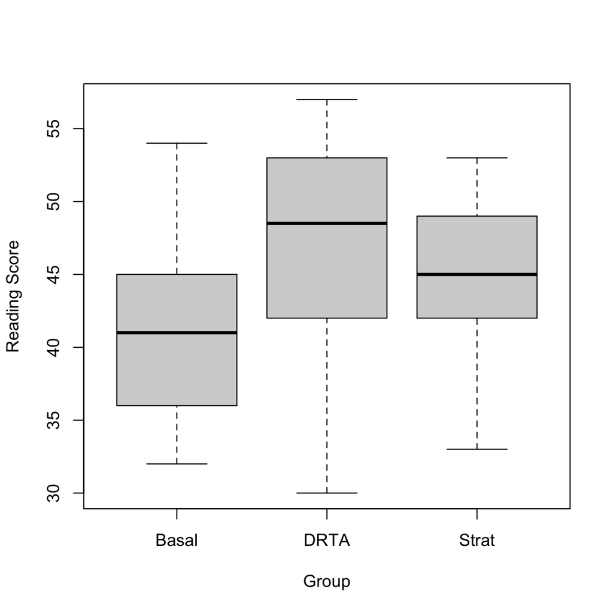

```r
plot(post.test.3 ~ group, data=Baumann, xlab="Group",
    ylab="Reading Score")
```

The means and boxplots suggest that there may be systematic differences in levels among the groups. The one-way ANOVA model can determine if the difference is significative

```r
S(baum.mod.1 <- lm(post.test.3 ~ group, data=Baumann))
```

```
Call: lm(formula = post.test.3 ~ group, data = Baumann)

Coefficients:
            Estimate Std. Error t value Pr(>|t|)
(Intercept)   41.045      1.346  30.490  < 2e-16 ***
groupDRTA      5.682      1.904   2.985  0.00404 **
groupStrat     3.227      1.904   1.695  0.09498 .
---
Signif. codes:  0 '***' 0.001 '**' 0.01 '*' 0.05 '.' 0.1 ' ' 1

Residual standard deviation: 6.314 on 63 degrees of freedom
Multiple R-squared: 0.1245
F-statistic: 4.481 on 2 and 63 DF,  p-value: 0.01515
   AIC    BIC
435.48 444.24
```

The pairwise comparisons of the means for the three groups can be obtained using the `emmeans` function. emmeans comes form “estimated marginal means”, the *emmeans* package enables users to easily obtain least-squares means for many linear, generalized linear, and mixed models as well as compute contrasts or linear functions of least-squares means, and comparisons of slopes.

```r
(emms.est1.baum.mod.1 <- emmeans(baum.mod.1, pairwise ~ group))
```

```
$emmeans
 group emmean   SE df lower.CL upper.CL
 Basal   41.0 1.35 63     38.4     43.7
 DRTA    46.7 1.35 63     44.0     49.4
 Strat   44.3 1.35 63     41.6     47.0

Confidence level used: 0.95

$contrasts
 contrast      estimate  SE df t.ratio p.value
 Basal - DRTA     -5.68 1.9 63 -2.985  0.0111
 Basal - Strat    -3.23 1.9 63 -1.695  0.2150
 DRTA - Strat      2.45 1.9 63  1.289  0.4064

P value adjustment: tukey method for comparing a family of 3 estimates
```

```r
(emms.est2.baum.mod.1 <- emmeans(baum.mod.1, trt.vs.ctrl ~ group))
```

```
$emmeans
 group emmean   SE df lower.CL upper.CL
 Basal   41.0 1.35 63     38.4     43.7
 DRTA    46.7 1.35 63     44.0     49.4
 Strat   44.3 1.35 63     41.6     47.0

Confidence level used: 0.95

$contrasts
 contrast      estimate  SE df t.ratio p.value
 DRTA - Basal      5.68 1.9 63 2.985   0.0079
 Strat - Basal     3.23 1.9 63 1.695   0.1712

P value adjustment: dunnettx method for 2 tests
```

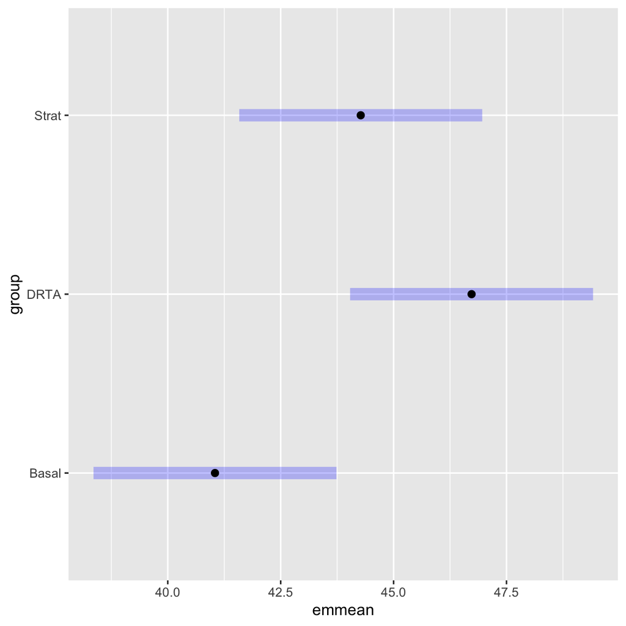

```r
plot(emms.est1.baum.mod.1)
```

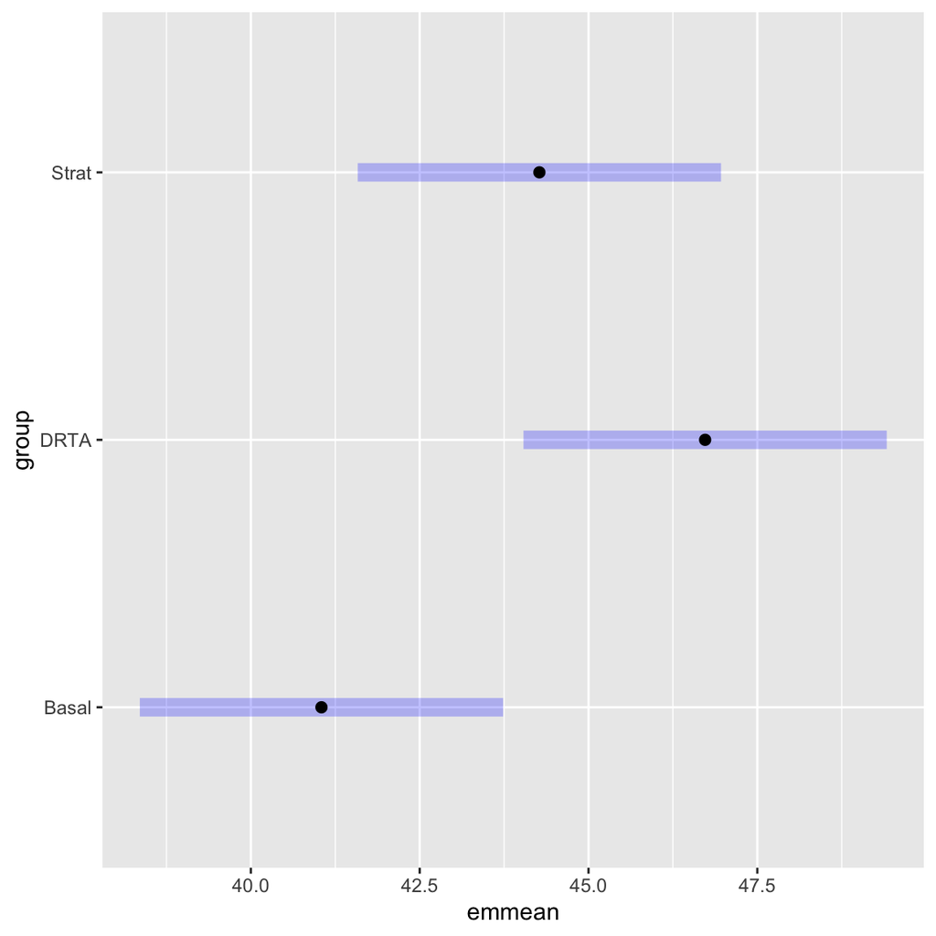

```r
plot(emms.est2.baum.mod.1)
```

[^1]: Notes taken form Chap 4 of Fox & Weisberg